# LungCapData

Amira Ibrahim

October 2, 2019

```r
LungCapData <- read.delim(file.choose(),header = TRUE)
attach(LungCapData)
```

# check names

```r
names(LungCapData)
```

```
## [1] "LungCap"   "Age"       "Height"    "Smoke"     "Gender"    "Caesarean"
```

# summary of data :

```r
summary(LungCapData)
```

```
##     LungCap            Age            Height      Smoke        Gender
##  Min.   : 0.507   Min.   : 3.00   Min.   :45.30   no :648   female:358
##  1st Qu.: 6.150   1st Qu.: 9.00   1st Qu.:59.90   yes: 77   male  :367
##  Median : 8.000   Median :13.00   Median :65.40
##  Mean   : 7.863   Mean   :12.33   Mean   :64.84
##  3rd Qu.: 9.800   3rd Qu.:15.00   3rd Qu.:70.30
##  Max.   :14.675   Max.   :19.00   Max.   :81.80
##  Caesarean
##  no :561
##  yes:164
##
##
##
##
```

# relation between Gender and Smoke :

```r
Table1 <- table(Gender ,Smoke)
Table1
```

```
##         Smoke
## Gender    no yes
##   female 314  44
##   male   334  33
```

Table1 : Gender according to Smoking status

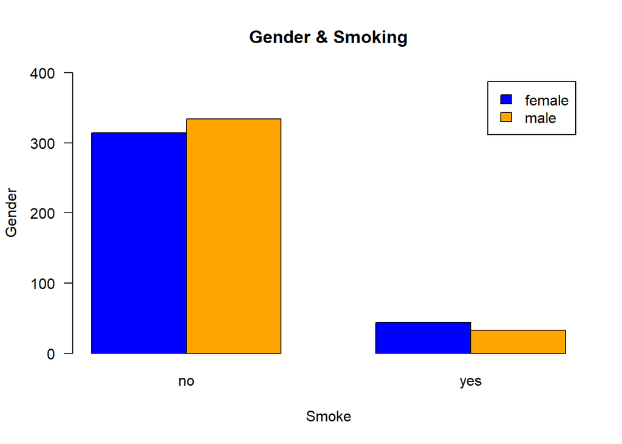

```r
barplot(Table1 , beside = TRUE , legend=TRUE ,xlab = "Smoke" , ylab = "Gender" ,
        main = "Gender & Smoking" ,ylim = c(0,400),col = c("blue" , "orange"),las=1 )
```

# categorical variables by chisq test :

## H0 : No relation between smoking frequency and gender

```r
chisq.test(Table1 , correct = TRUE)
```

```
##
##  Pearson's Chi-squared test with Yates' continuity correction
##
## data:  Table1
## X-squared = 1.7443, df = 1, p-value = 0.1866
```

### p-value > 0.05 , Fail to reject H0

# calculate OR , RR :

```r
library(epiR)
epi.2by2(Table1 , method = "cohort.count" , conf.level = 0.95)
```

```
##              Outcome +    Outcome -      Total        Inc risk *
## Exposed +          314           44        358              87.7
## Exposed -          334           33        367              91.0
## Total              648           77        725              89.4
##                  Odds
## Exposed +        7.14
## Exposed -       10.12
## Total            8.42
##
## Point estimates and 95% CIs:
## -------------------------------------------------------------------
## Inc risk ratio                               0.96 (0.92, 1.01)
## Odds ratio                                   0.71 (0.44, 1.14)
## Attrib risk *                                -3.30 (-7.79, 1.19)
## Attrib risk in population *                  -1.63 (-5.32, 2.06)
## Attrib fraction in exposed (%)               -3.76 (-9.12, 1.34)
## Attrib fraction in population (%)            -1.82 (-4.34, 0.64)
## -------------------------------------------------------------------
##  Test that odds ratio = 1: chi2(1) = 2.077 Pr>chi2 = 0.15
##  Wald confidence limits
##  CI: confidence interval
##  * Outcomes per 100 population units
```

### Odds of Females not smoking are 0.71 times odds of males not smoking

```r
1/0.71
```

```
## [1] 1.408451
```

### Odds of males not smoking are 1.4 times odds of Females not smoking

# check normality

```r
library(moments)
skewness(LungCap)
```

```
## [1] -0.2274017
```

### accepted level from -1 to +1

```r
kurtosis(LungCap)
```

```
## [1] 2.68148
```

### accepted level from -2 to +2 may to +3

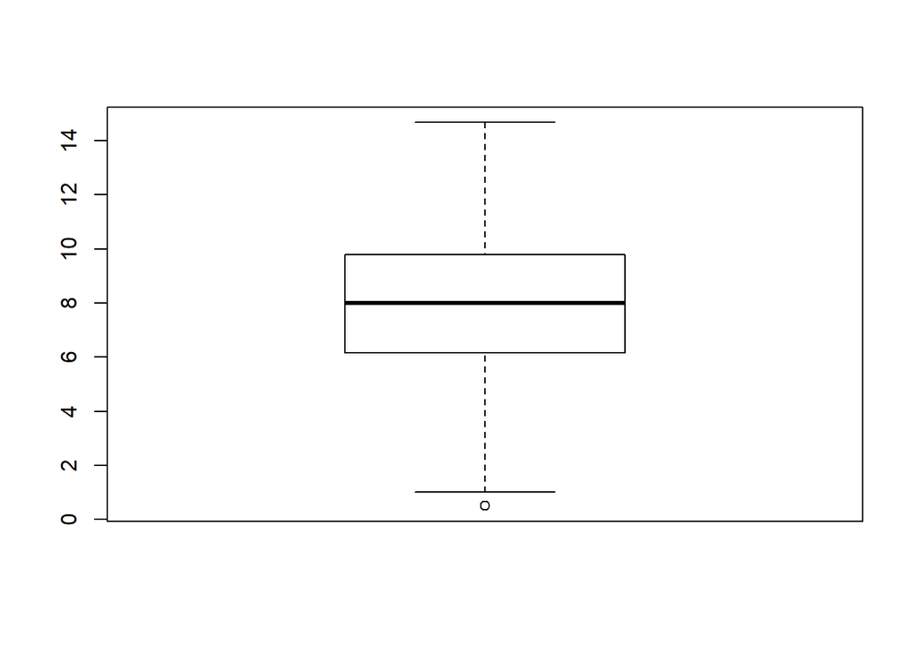

```r
boxplot(LungCap)
```

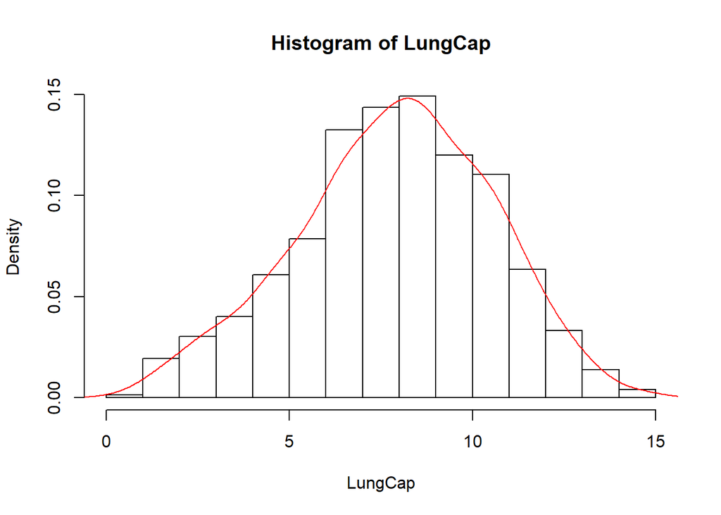

```r
hist(LungCap,freq = FALSE)
lines(density(LungCap),col="red",lwd=1)
```

###visually ,data is normally distributed

# One-sample t-test for lung Capacity :

## Test H0 =8 , conf.interval = 0.95 :

```r
t.test(LungCap , mu=8 , alternative = "two.sided" , conf.level = 0.95)
```

```
##
##  One Sample t-test
##
## data:  LungCap
## t = -1.3842, df = 724, p-value = 0.1667
## alternative hypothesis: true mean is not equal to 8
## 95 percent confidence interval:
##  7.669052 8.057243
## sample estimates:
## mean of x
##  7.863148
```

### p-value >0.05 , fail to reject H0

# Relation between Smoke & lung Capacity :

## H0 : mean of smokers = mean of non smokers :

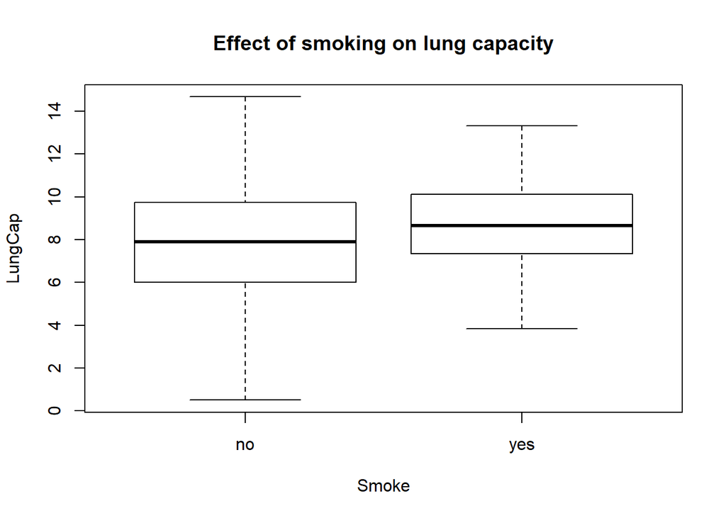

```r
boxplot(LungCap~Smoke , main = "Effect of smoking on lung capacity")
```

# check variance :

```r
var(LungCap[Smoke == "yes"])
```

```
## [1] 3.545292
```

```r
var(LungCap[Smoke == "no"])
```

```
## [1] 7.431694
```

### so variance not equal

```r
t.test(LungCap~Smoke , mu=0 , alternative = "two.sided" , var.eq = F, conf.level =  0.95)
```

```
##
##  Welch Two Sample t-test
##
## data:  LungCap by Smoke
## t = -3.6498, df = 117.72, p-value = 0.0003927
## alternative hypothesis: true difference in means is not equal to 0
## 95 percent confidence interval:
##  -1.3501778 -0.4003548
## sample estimates:
##  mean in group no mean in group yes
##          7.770188          8.645455
```

### p-value < 0.05 , reject H0 , Smoking has a significant effect on lung capacity

# fit a model of the relation between Age , LungCap :

## use simple linear regression

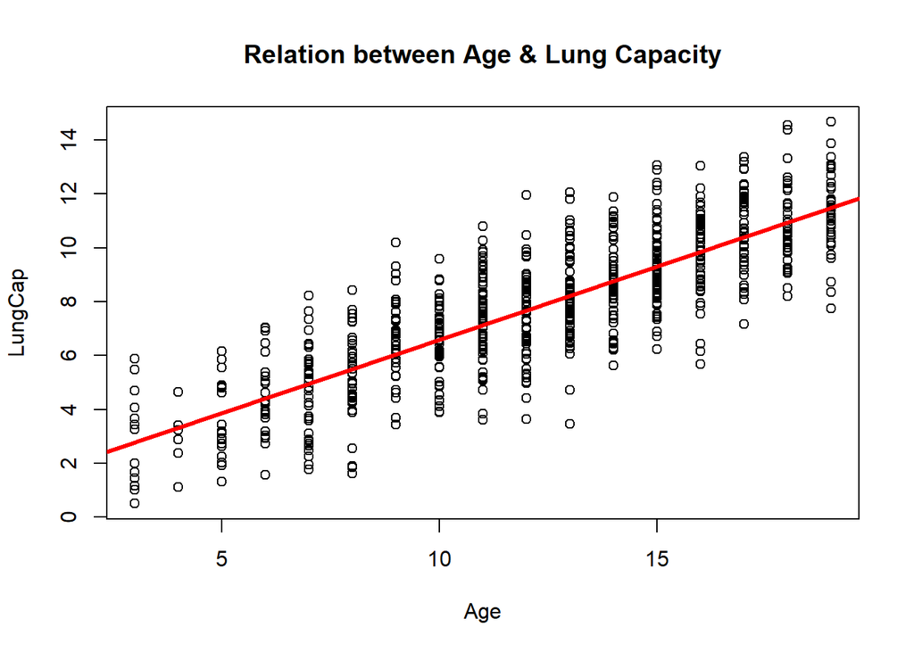

```r
model1 <- lm(LungCap~Age)
plot(Age,LungCap,main = "Relation between Age & Lung Capacity")
abline(model1 ,col=2 , lwd=3)
```

# correlation between Lung capacity & Age

```r
cor(Age,LungCap ,method="pearson")
```

```
## [1] 0.8196749
```

### there is +ve strong correlation

# Denisty plots : check if the response variable is close to normal :

```r
library(e1071)
```

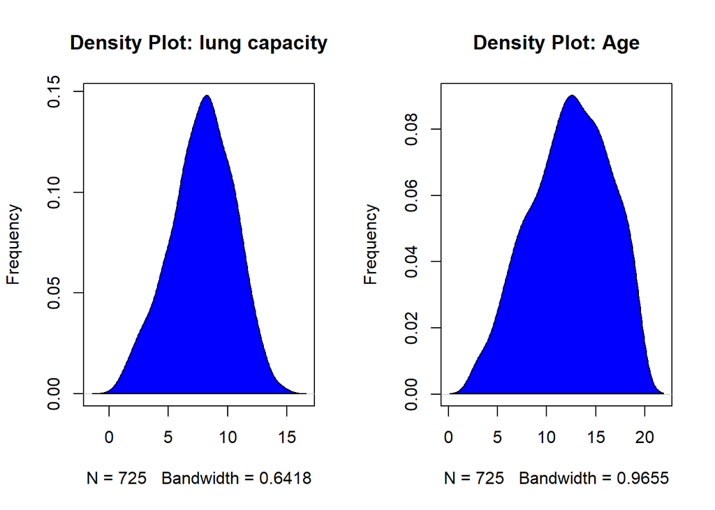

```r
par(mfrow=c(1, 2))  # divide graph area in 2 columns
plot(density(LungCap), main="Density Plot: lung capacity", ylab="Frequency")
# density plot for 'lung capacity'
polygon(density(LungCap), col="blue")
plot(density(Age), main="Density Plot: Age", ylab="Frequency")  # density plot for 'dist'
polygon(density(Age), col="blue")
```

# built linear model equation :

```r
model1 <- lm(LungCap~Age)
model1
```

```
##
## Call:
## lm(formula = LungCap ~ Age)
##
## Coefficients:
## (Intercept)          Age
##      1.1469       0.5448
```

### Equation : lungCap = 1.1469 + 0.5448 * Age

### increase in 1 year of Age associated with 0.5448 increase in lung Capacity

# check the residuals and significance

H0 : slope = 0

```r
summary(model1)
```

```
##
## Call:
## lm(formula = LungCap ~ Age)
##
## Residuals:
##     Min      1Q  Median      3Q     Max
## -4.7799 -1.0203 -0.0005  0.9789  4.2650
##
## Coefficients:
##             Estimate Std. Error t value Pr(>|t|)
## (Intercept)  1.14686    0.18353   6.249 7.06e-10 ***
## Age          0.54485    0.01416  38.476  < 2e-16 ***
## ---
## Signif. codes:  0 '***' 0.001 '**' 0.01 '*' 0.05 '.' 0.1 ' ' 1
##
## Residual standard error: 1.526 on 723 degrees of freedom
## Multiple R-squared:  0.6719, Adjusted R-squared:  0.6714
## F-statistic:  1480 on 1 and 723 DF,  p-value: < 2.2e-16
```

### p-value <0.05 , reject H0 ,there is significant diffrence

### 67% of the variation in Lung Capicity is explained by Age

# test H0: variation mean squared regression = variation mean squared errors

```r
anova(model1)
```

```
## Analysis of Variance Table
##
## Response: LungCap
##            Df Sum Sq Mean Sq F value    Pr(>F)
## Age         1 3447.0  3447.0  1480.4 < 2.2e-16 ***
## Residuals 723 1683.5     2.3
## ---
## Signif. codes:  0 '***' 0.001 '**' 0.01 '*' 0.05 '.' 0.1 ' ' 1
```

```r
sqrt(2.3)
```

```
## [1] 1.516575
```

### p-value < 0.05 , reject H0

# Getting the coeffecient confedience interval :

```r
confint(model1)
```

```
##                 2.5 %    97.5 %
## (Intercept) 0.7865454 1.5071702
## Age         0.5170471 0.5726497
```

### confedience interval not pass through zero , there is significant diffrence

# visualize the assumption

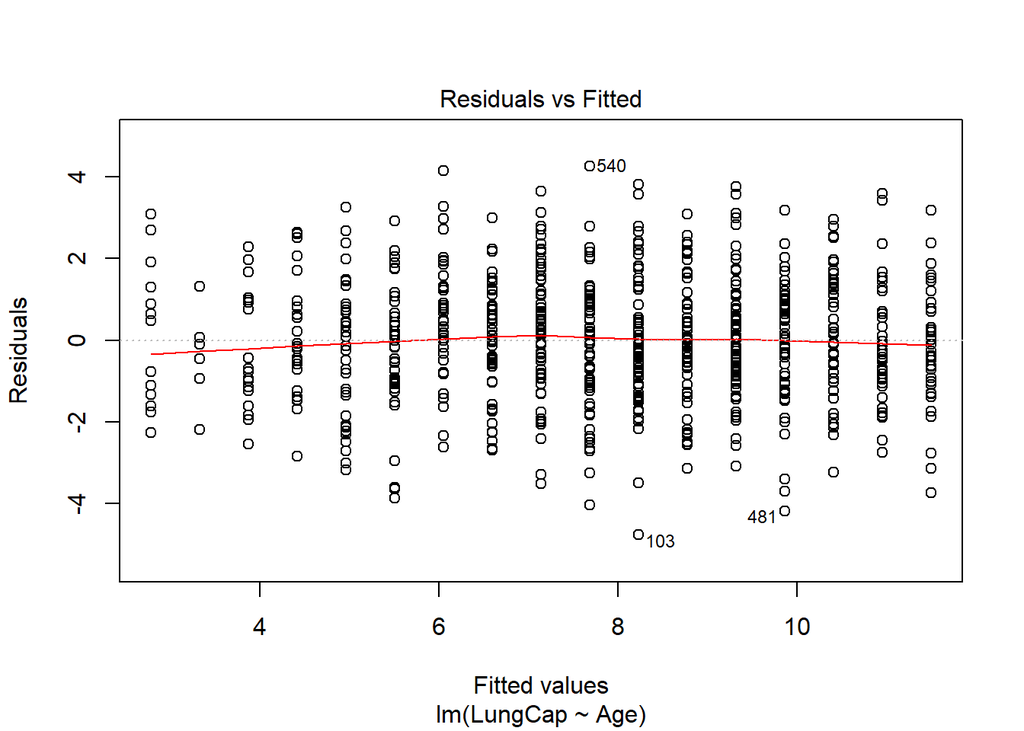

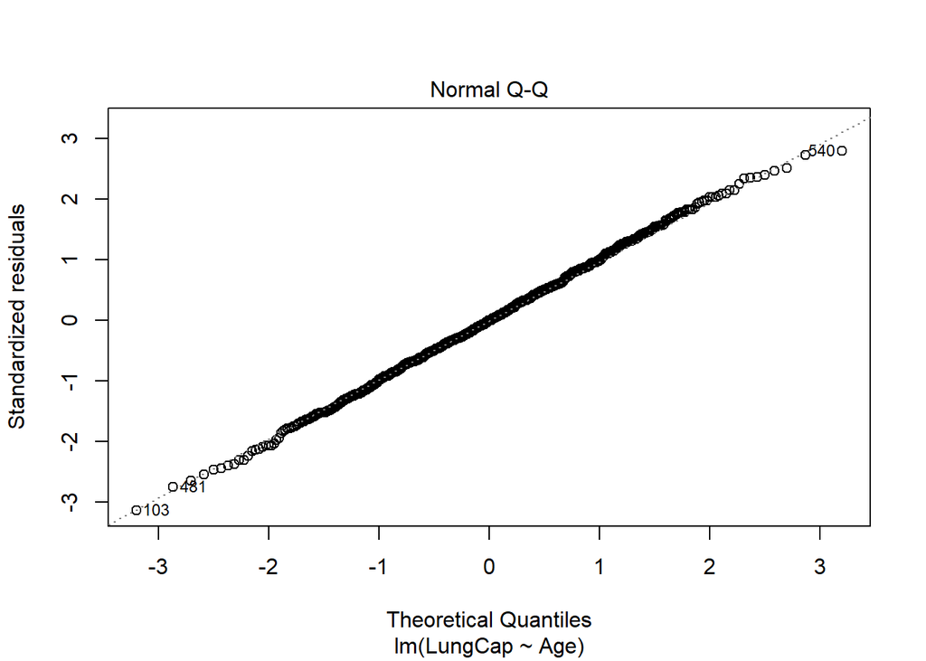

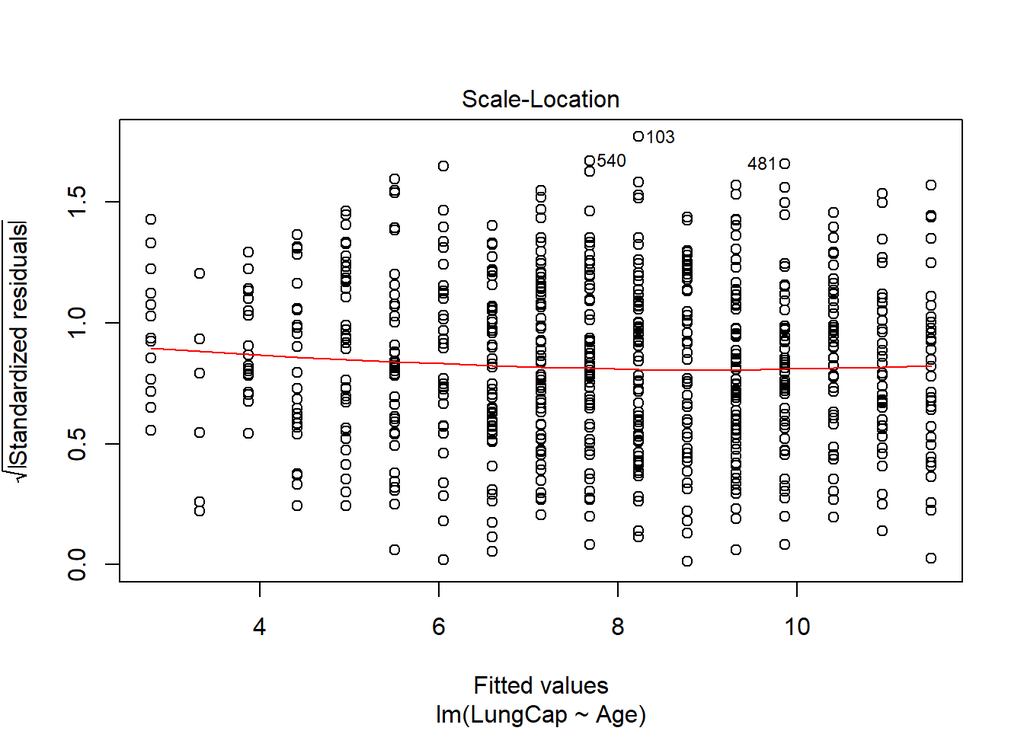

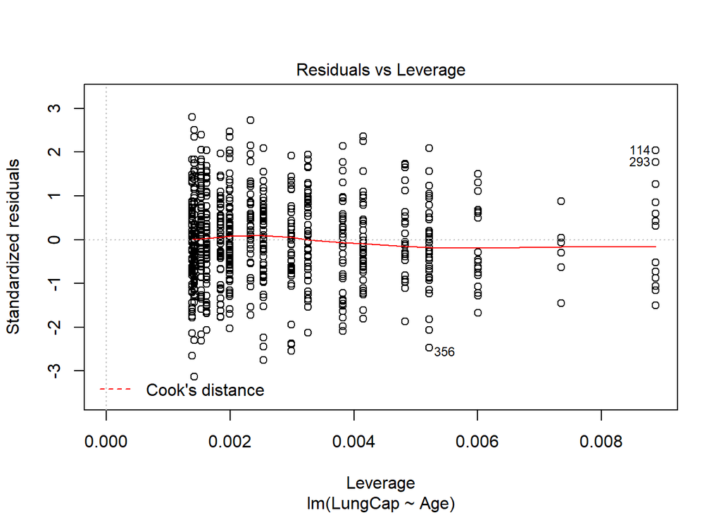

```r
plot(model1)
```

The diagnostic plots show residuals in four different ways:

Residuals vs Fitted. Used to check the linear relationship assumptions. A horizontal line, without distinct patterns is an indication for a linear relationship, what is good.

Normal Q-Q. Used to examine whether the residuals are normally distributed. It’s good if residuals points follow the straight dashed line.

Scale-Location (or Spread-Location). Used to check the homogeneity of variance of the residuals (homoscedasticity). Horizontal line with equally spread points is a good indication of homoscedasticity.

Residuals vs Leverage. Used to identify influential cases, that is extreme values that might influence the regression results when included or excluded from the analysis.

# fit a model using Age & Height as explanatory variables :

## H0 B0=B1=B2= 0

```r
mlr <- lm(LungCap~Age+Height , data = LungCapData)
summary(mlr)
```

```
##
## Call:
## lm(formula = LungCap ~ Age + Height, data = LungCapData)
##
## Residuals:
##     Min      1Q  Median      3Q     Max
## -3.4080 -0.7097 -0.0078  0.7167  3.1679
##
## Coefficients:
##               Estimate Std. Error t value Pr(>|t|)
## (Intercept) -11.747065   0.476899 -24.632  < 2e-16 ***
## Age           0.126368   0.017851   7.079 3.45e-12 ***
## Height        0.278432   0.009926  28.051  < 2e-16 ***
## ---
## Signif. codes:  0 '***' 0.001 '**' 0.01 '*' 0.05 '.' 0.1 ' ' 1
##
## Residual standard error: 1.056 on 722 degrees of freedom
## Multiple R-squared:  0.843,  Adjusted R-squared:  0.8425
## F-statistic:  1938 on 2 and 722 DF,  p-value: < 2.2e-16
```

### p-value < 0.05 , reject H0

### 84.25% of variation in lung capacity is explained by Age and Height

### Equation : lung capacity = -11.747 + (0.126*Age) + (0.278*Height)

### increase in 1 year of Age with an increase in 0.126 of lung capacity adjusting for Height

# pearson correlation between Age ,Height :

```r
cor(Age , Height, method = "pearson")
```

```
## [1] 0.8357368
```

### there is +ve strong correlation

# Getting the coeffecient confedience interval :

```r
confint(mlr)
```

```
##                    2.5 %      97.5 %
## (Intercept) -12.68333877 -10.8107918
## Age           0.09132215   0.1614142
## Height        0.25894454   0.2979192
```

### confedience interval not pass through zero , there is significant diffrence

# visualize the assumption

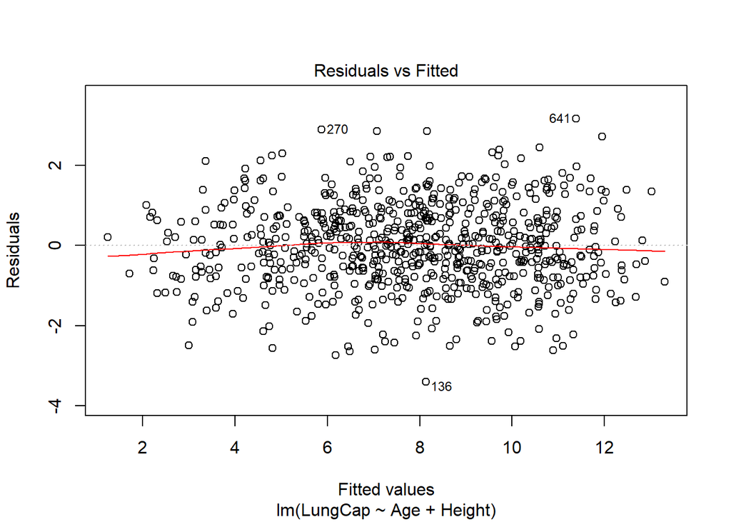

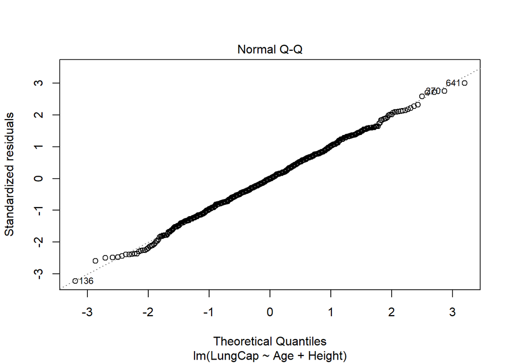

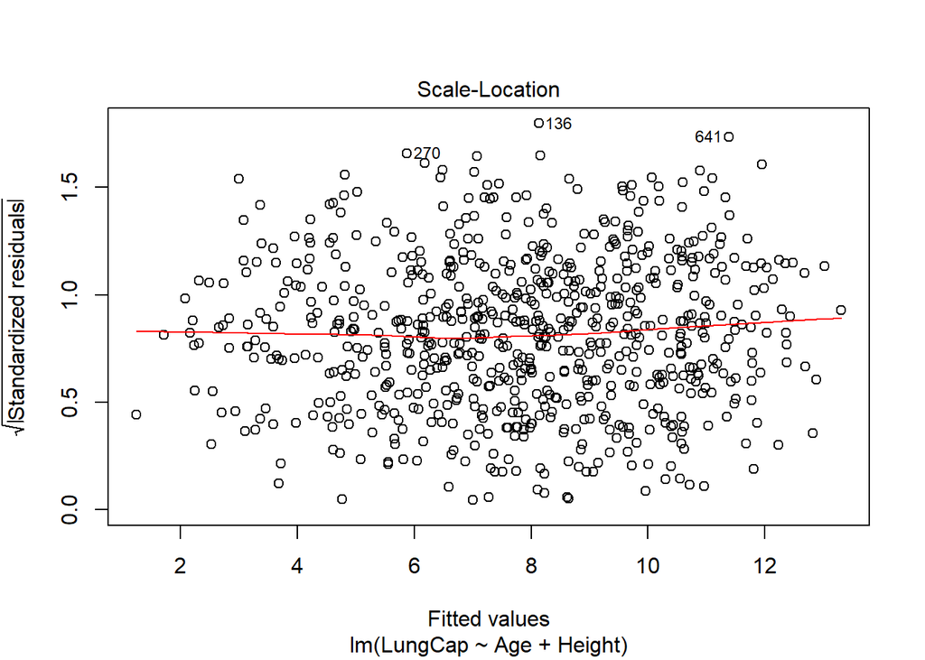

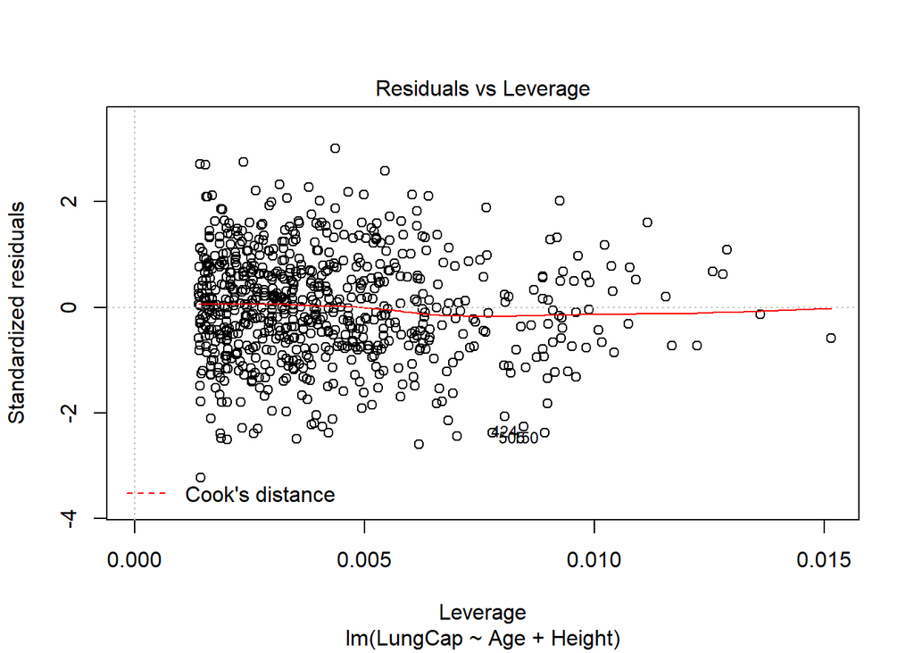

```r
plot(mlr)
```

The diagnostic plots show residuals in four different ways:

Residuals vs Fitted. Used to check the linear relationship assumptions. A horizontal line, without distinct patterns is an indication for a linear relationship, what is good.

Normal Q-Q. Used to examine whether the residuals are normally distributed. It’s good if residuals points follow the straight dashed line.

Scale-Location (or Spread-Location). Used to check the homogeneity of variance of the residuals (homoscedasticity). Horizontal line with equally spread points is a good indication of homoscedasticity.

Residuals vs Leverage. Used to identify influential cases, that is extreme values that might influence the regression results when included or excluded from the analysis.

# If we convert Height into categorical variable:

creat Height categorical A<50 , B=50-55 , c=55-60 , D=60-65 , E=65-70 , F>70

```r
CatHeight <- cut(Height,breaks = c(0,50,55,60,65,70,100), labels = c("A","B","C","D","E","F"))
```

# fit model using Age , Height (as categorical variable) as explanatory variables :

```r
m2 <- lm(LungCap~Age+CatHeight)
summary(m2)
```

```
##
## Call:
## lm(formula = LungCap ~ Age + CatHeight)
##
## Residuals:
##     Min      1Q  Median      3Q     Max
## -3.8719 -0.7751  0.0281  0.7521  3.4160
##
## Coefficients:
##             Estimate Std. Error t value Pr(>|t|)
## (Intercept)  0.97553    0.29394   3.319  0.00095 ***
## Age          0.20110    0.01859  10.816  < 2e-16 ***
## CatHeightB   1.48361    0.31780   4.668 3.62e-06 ***
## CatHeightC   2.68562    0.29818   9.007  < 2e-16 ***
## CatHeightD   3.93857    0.30623  12.862  < 2e-16 ***
## CatHeightE   5.00703    0.32105  15.596  < 2e-16 ***
## CatHeightF   6.53873    0.34635  18.879  < 2e-16 ***
## ---
## Signif. codes:  0 '***' 0.001 '**' 0.01 '*' 0.05 '.' 0.1 ' ' 1
##
## Residual standard error: 1.159 on 718 degrees of freedom
## Multiple R-squared:  0.812,  Adjusted R-squared:  0.8104
## F-statistic: 516.8 on 6 and 718 DF,  p-value: < 2.2e-16
```

### Lung capacity = 0.976+ 0.201*Age + 1.484*Xb + 2.686*Xc + 3.939*Xd + 5.007*Xe + 6.539*Xf

### lung capacity for category A = 0.976 + 0.201*Age ###lung capacity for category B = 2.46 + 0.201*Age

### lung capacity for category c = 3.67 + 0.201*Age ###lung capacity for category D = 4.92 + 0.201*Age

# plot Data with different colors For Height categories:

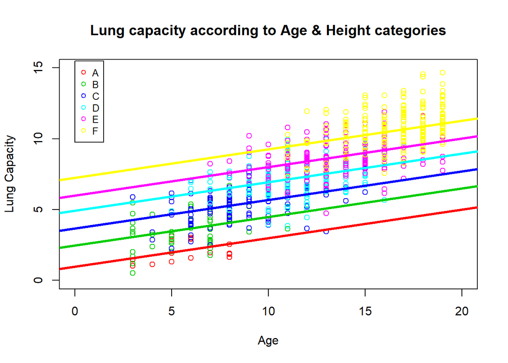

```r
plot(Age[CatHeight=="A"],LungCap[CatHeight=="A"] , col=2,xlim = c(0,20), ylim = c(0,15),xlab = "Age" , ylab = "Lung Capacity" , main = "Lung capacity according to Age & Height categories")
points(Age[CatHeight=="B"], LungCap[CatHeight=="B"],col=3)
points(Age[CatHeight=="C"], LungCap[CatHeight=="C"],col=4)
points(Age[CatHeight=="D"], LungCap[CatHeight=="D"],col=5)
points(Age[CatHeight=="E"], LungCap[CatHeight=="E"],col=6)
points(Age[CatHeight=="F"], LungCap[CatHeight=="F"],col=7)
legend(0,15.5,legend = c("A","B","C","D","E","F"),col = 2:7,pch = 1,cex = 0.8)
abline(a=0.976,b=0.201,col=2,lwd=3)
abline(a=2.46,b=0.201,col=3,lwd=3)
abline(a=3.67,b=0.201,col=4,lwd=3)
abline(a=4.92,b=0.201,col=5,lwd=3)
abline(a=5.99,b=0.201,col=6,lwd=3)
abline(a=7.25,b=0.201,col=7,lwd=3)
```

###increase in 1 year associate with 0.201 change in lung capacity independent on Height categories

### Age effect is the same for all Height categories

# visualize the assumption

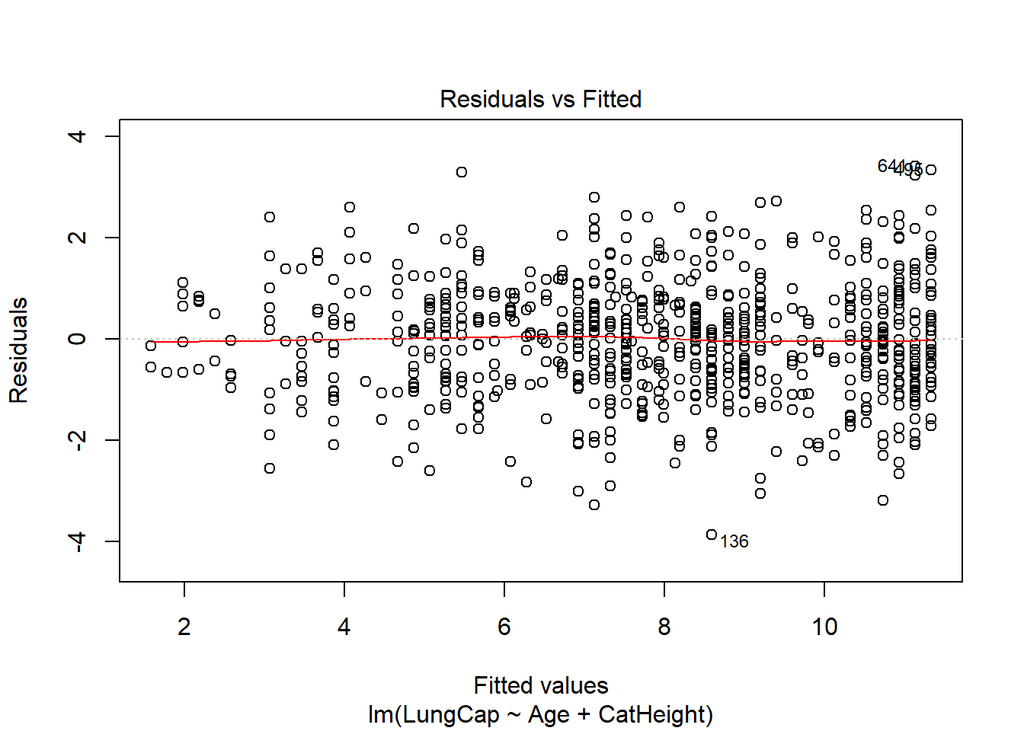

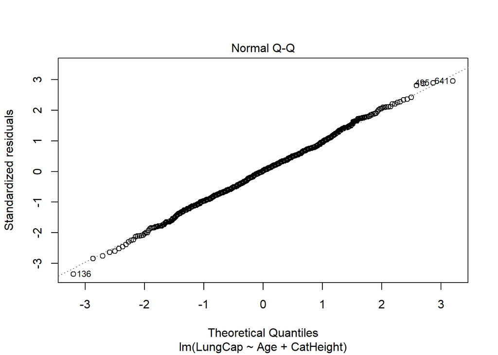

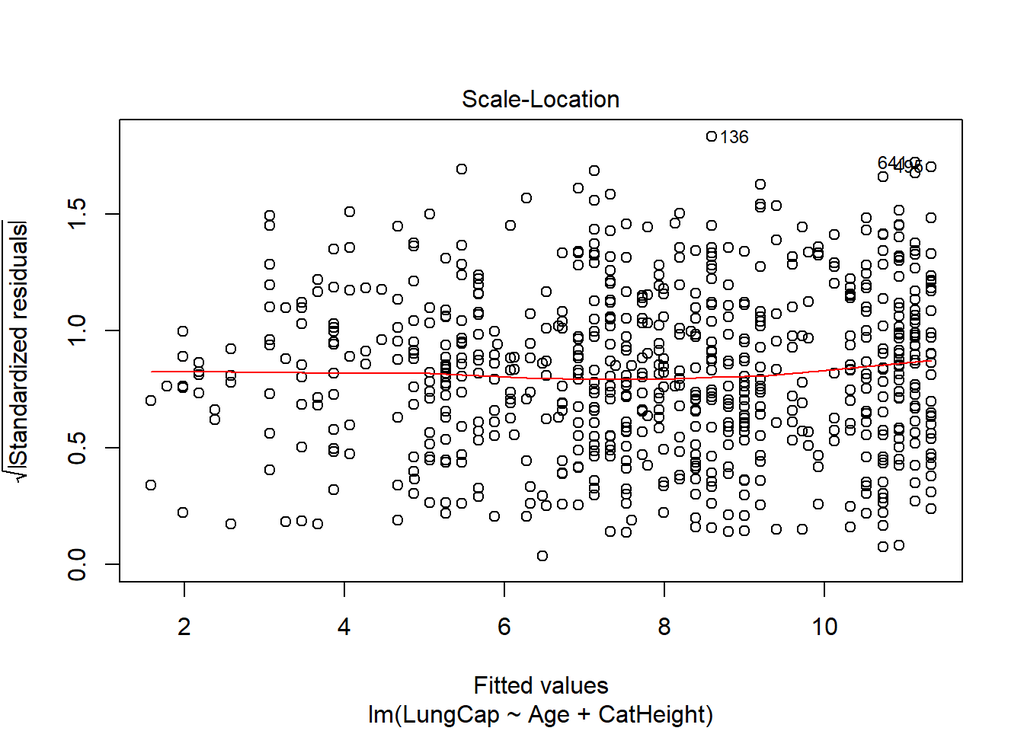

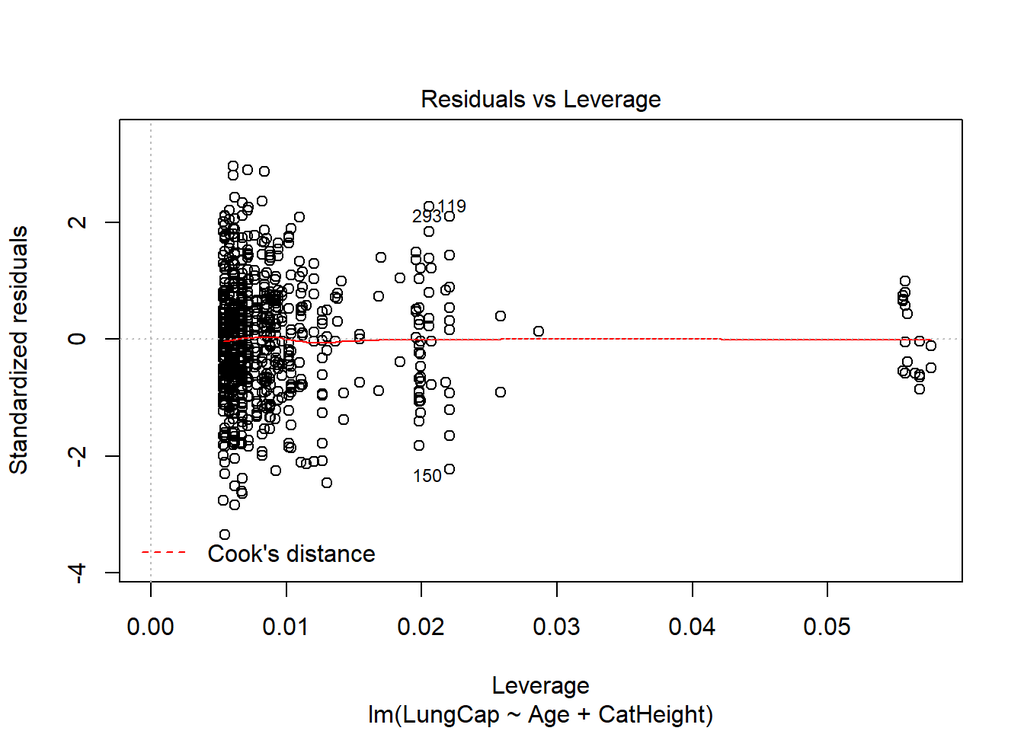

```r
plot(m2)
```

The diagnostic plots show residuals in four different ways:

Residuals vs Fitted. Used to check the linear relationship assumptions. A horizontal line, without distinct patterns is an indication for a linear relationship, what is good.

Normal Q-Q. Used to examine whether the residuals are normally distributed. It’s good if residuals points follow the straight dashed line.

Scale-Location (or Spread-Location). Used to check the homogeneity of variance of the residuals (homoscedasticity). Horizontal line with equally spread points is a good indication of homoscedasticity.

Residuals vs Leverage. Used to identify influential cases, that is extreme values that might influence the regression results when included or excluded from the analysis.

# fit model using Age , Smoking as explanatory variables :

```r
mlr1 <- lm(LungCap~Age+Smoke)
summary(mlr1)
```

```
##
## Call:
## lm(formula = LungCap ~ Age + Smoke)
##
## Residuals:
##     Min      1Q  Median      3Q     Max
## -4.8559 -1.0289 -0.0363  1.0083  4.1995
##
## Coefficients:
##             Estimate Std. Error t value Pr(>|t|)
## (Intercept)  1.08572    0.18299   5.933 4.61e-09 ***
## Age          0.55540    0.01438  38.628  < 2e-16 ***
## Smokeyes    -0.64859    0.18676  -3.473 0.000546 ***
## ---
## Signif. codes:  0 '***' 0.001 '**' 0.01 '*' 0.05 '.' 0.1 ' ' 1
##
## Residual standard error: 1.514 on 722 degrees of freedom
## Multiple R-squared:  0.6773, Adjusted R-squared:  0.6764
## F-statistic: 757.5 on 2 and 722 DF,  p-value: < 2.2e-16
```

### 67% of variation in lung capacity is explained by Age & Smoke

### Equation : LungCap = 1.086 + (0.555*Age) +(-0.649*Smoke yes)

### lung capacity in non smokers = 1.086 + (0.555*Age)

### lung capacity in smokers = 0.437 + (0.555*Age)

# Plot the data to differ between Smokers & non smokers :

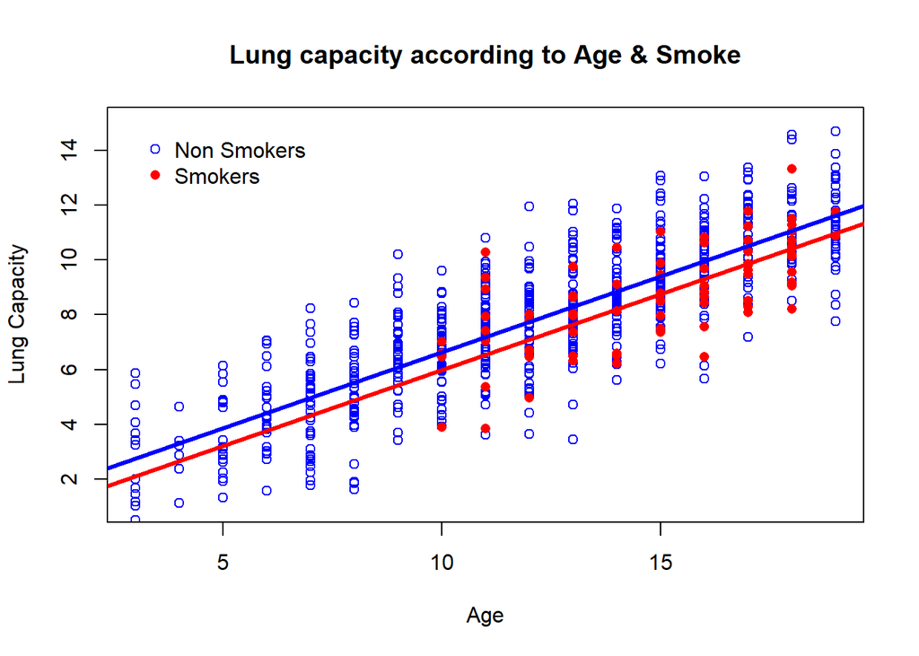

```r
plot(Age[Smoke=="no"],LungCap[Smoke=="no"] , col="blue" , ylim = c(1,15),xlab = "Age" , ylab = "Lung Capacity" , main = "Lung capacity according to Age & Smoke")
points(Age[Smoke=="yes"], LungCap[Smoke=="yes"],col="red",pch=16)
legend(3,15,legend = c("Non Smokers","Smokers"),col = c("blue","red"),pch = c(1,16),bty = "n")
abline(a=1.08,b=0.555,col="blue",lwd=3)
abline(a=0.431,b=0.555,col="red",lwd=3)
```

###increase in 1 year associate with 0.555 change in mean lung capacity , this increase is the same in Smokers & non Smokers

### For Smokers mean lung capacity decreased by 0.649 ,this decrease is the same in All ages

### Effect of Age is independent on Smoking & vise versa , So no interaction between Age and Smoke

# Getting the coeffecient confedience interval :

```r
confint(mlr1)
```

```
##                  2.5 %     97.5 %
## (Intercept)  0.7264702  1.4449793
## Age          0.5271678  0.5836240
## Smokeyes    -1.0152473 -0.2819294
```

# visualize the assumption

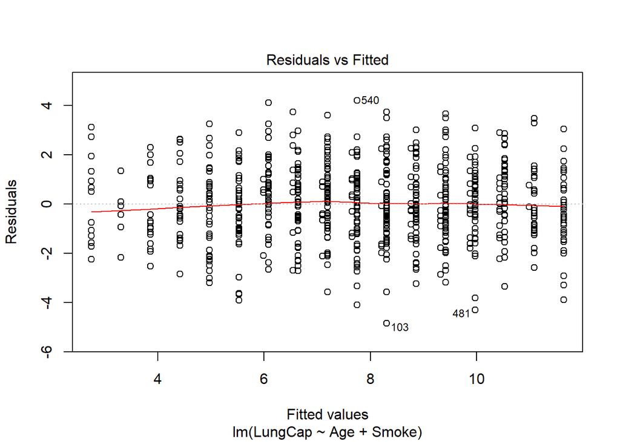

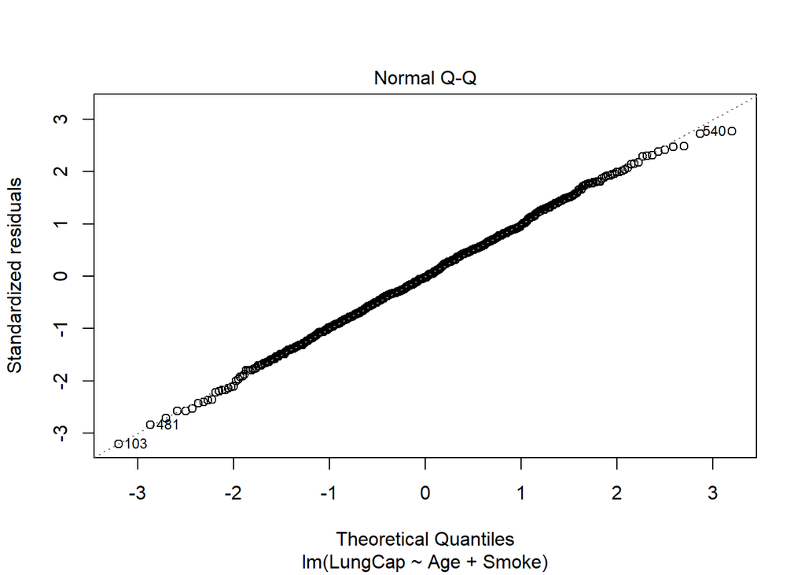

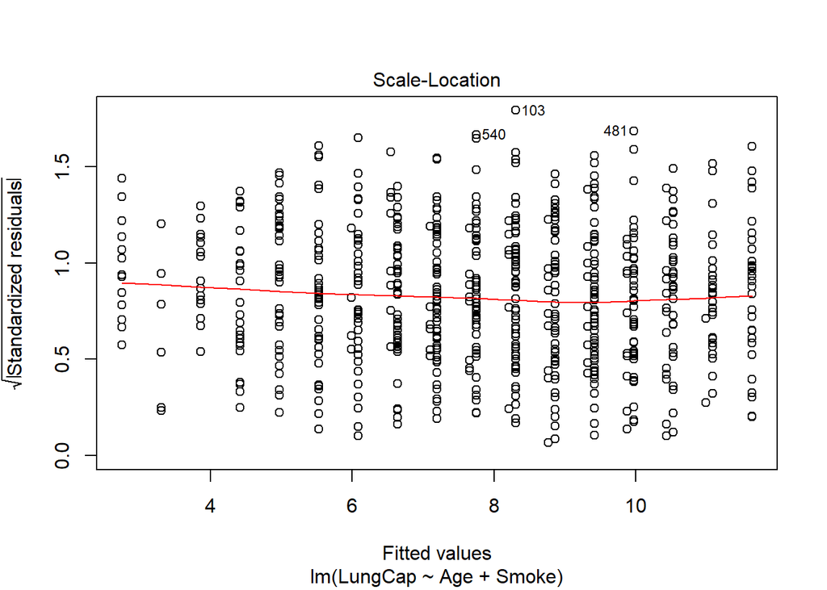

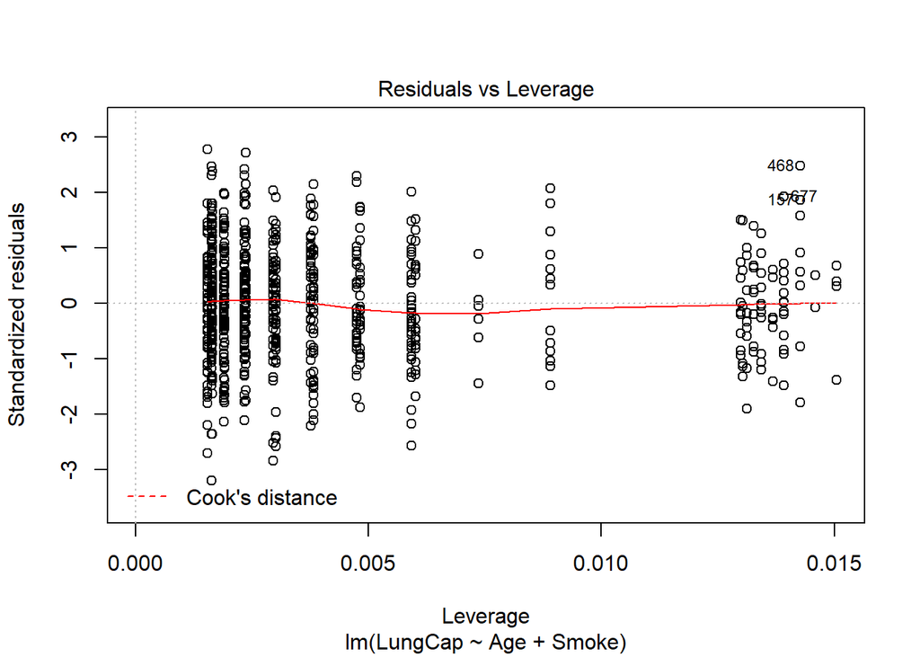

```r
plot(mlr1)
```

The diagnostic plots show residuals in four different ways:

Residuals vs Fitted. Used to check the linear relationship assumptions. A horizontal line, without distinct patterns is an indication for a linear relationship, what is good.

Normal Q-Q. Used to examine whether the residuals are normally distributed. It’s good if residuals points follow the straight dashed line.

Scale-Location (or Spread-Location). Used to check the homogeneity of variance of the residuals (homoscedasticity). Horizontal line with equally spread points is a good indication of homoscedasticity.

Residuals vs Leverage. Used to identify influential cases, that is extreme values that might influence the regression results when included or excluded from the analysis.

# fit model for all variables

```r
mlr2 <- lm(LungCap~ Age+Height+Smoke+Gender+Caesarean,data = LungCapData)
summary(mlr2)
```

```
##
## Call:
## lm(formula = LungCap ~ Age + Height + Smoke + Gender + Caesarean,
##     data = LungCapData)
##
## Residuals:
##     Min      1Q  Median      3Q     Max
## -3.3388 -0.7200  0.0444  0.7093  3.0172
##
## Coefficients:
##               Estimate Std. Error t value Pr(>|t|)
## (Intercept)  -11.32249    0.47097 -24.041  < 2e-16 ***
## Age            0.16053    0.01801   8.915  < 2e-16 ***
## Height         0.26411    0.01006  26.248  < 2e-16 ***
## Smokeyes      -0.60956    0.12598  -4.839 1.60e-06 ***
## Gendermale     0.38701    0.07966   4.858 1.45e-06 ***
## Caesareanyes  -0.21422    0.09074  -2.361   0.0185 *
## ---
## Signif. codes:  0 '***' 0.001 '**' 0.01 '*' 0.05 '.' 0.1 ' ' 1
##
## Residual standard error: 1.02 on 719 degrees of freedom
## Multiple R-squared:  0.8542, Adjusted R-squared:  0.8532
## F-statistic: 842.8 on 5 and 719 DF,  p-value: < 2.2e-16
```

### 85.32% of variation in Lung capacity is explained by other variables

[output not shown]

### Lung Capacity of non Smokers females (caesarean) = -11.53 + (0.16*Age) + (0.26*Height)

### Lung Capacity of non Smokers females (non caesarean) = -11.32 + (0.16*Age) + (0.26*Height)

# Getting the coeffecient confedience interval :

```r
confint(mlr2)
```

```
##                    2.5 %       97.5 %
## (Intercept)  -12.2471338 -10.39783728
## Age            0.1251765   0.19588271
## Height         0.2443581   0.28386751
## Smokeyes      -0.8568861  -0.36223237
## Gendermale     0.2306230   0.54340035
## Caesareanyes  -0.3923590  -0.03607738
```

### confedience interval not pass through zero , there is significant diffrence

# visualize the assumption

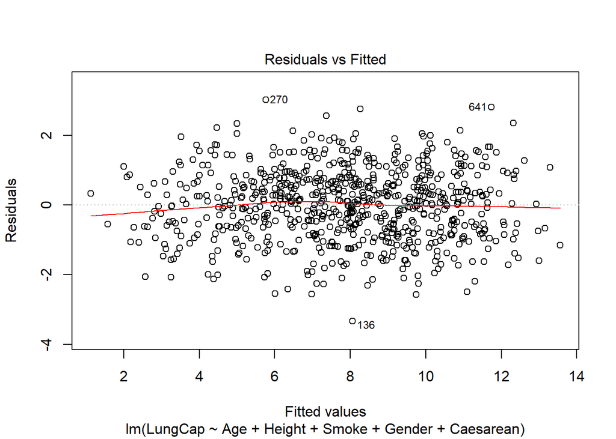

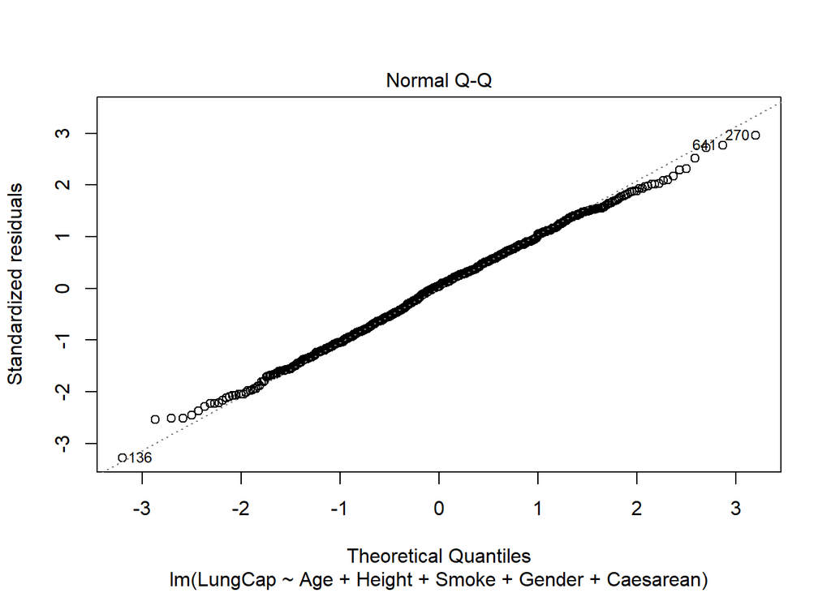

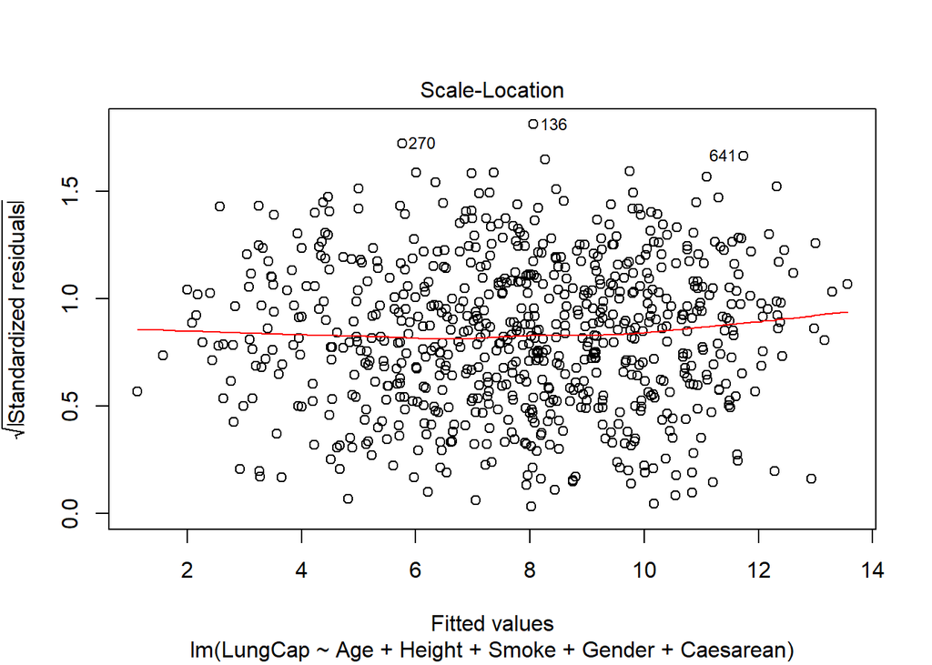

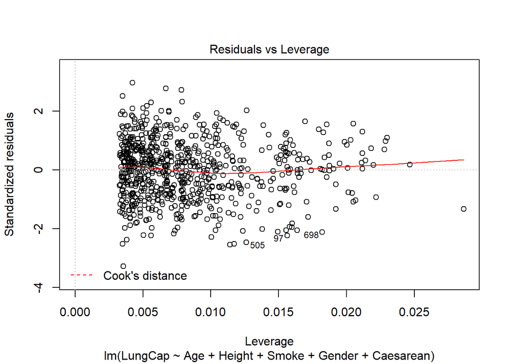

```r
plot(mlr2)
```

The diagnostic plots show residuals in four different ways:

Residuals vs Fitted. Used to check the linear relationship assumptions. A horizontal line, without distinct patterns is an indication for a linear relationship, what is good.

Normal Q-Q. Used to examine whether the residuals are normally distributed. It’s good if residuals points follow the straight dashed line.

Scale-Location (or Spread-Location). Used to check the homogeneity of variance of the residuals (homoscedasticity). Horizontal line with equally spread points is a good indication of homoscedasticity.

Residuals vs Leverage. Used to identify influential cases, that is extreme values that might influence the regression results when included or excluded from the analysis.